# Choose Mock Community Composition

M Fisher

1/26/2021

# Description

Use the lane 1 data set to identify taxa that should be included in mock communities.

# Set up

This script requires the following packages:

```r
library(here)
library(tidyverse)
library(magrittr)
library(cowplot)
```

# Leray XT

```r
marker <- 'LerayXT'
```

User directories

```r
indir_blast  <- 'test-lane-1/data/blast'
indir_asv    <- 'test-lane-1/data/dada2/LerayXT'
indir_meta   <- 'test-lane-1/data/cutadapt/LerayXT'
outdir       <- 'test-lane-1/results'
```

What are the names of the processed blast file with taxonomy from script 6?

```r
# hashes with unique staxids
infile1 <- 'lane1_lerayxt_blast_uniqueIDs_taxonomy.csv'

# hashes with multiple IDs, that required the LCA function
infile2 <- 'lane1_lerayxt_blast_multipleIDs_taxonomy.csv'
```

## Data

Taxonomy from script `6.parse.blast.results`

```r
tax_key <- read_csv(here(indir_blast, infile2)) %>%
  rename("Hash"=representative)
tax_key %<>% bind_rows(read_csv(here(indir_blast, infile1)) %>%
              rename("Hash"=qseqid) %>%
                mutate(taxID="unique", score="unique") %>%
              dplyr::select(all_of(colnames(tax_key))))
```

Sequencing sample metadata, so that we can connect sample name (actually a number; in the ASV table) to sample ID.

```r
metadat <- read_csv(here(indir_meta, paste0('cutadapt_output_metadata_',marker,'.csv')))
metadat %<>% dplyr::select(Sample_name, file1) %>%
  mutate(SampleID=str_remove(file1,"_L001_R1_001.fastq.fastq")) %>%
  mutate(SampleID=str_remove(SampleID,paste0("Locus_",marker,"_LXT_"))) %>%
  mutate(SampleID=ifelse(as.numeric(Sample_name) > 10, str_sub(SampleID,start=1, end=-5),
                         str_sub(SampleID,start=1, end=-4))) %>%
  mutate(Group=ifelse(SampleID %in% c("Kangaroo","PCRNegative","SpeedVacNegative"), "Control", str_sub(SampleID, start=1,end=4))) %>%
  mutate(Group=ifelse(Group!="WASS",Group,ifelse(grepl("2020",SampleID),"WASS 2020", "WASS 2018"))) %>%
  dplyr::select(-file1)
```

merged ASV table

```r
mdat <- read_csv(here(indir_asv, 'merged_ASV_table.csv')) %>%
  mutate(dataset="merged")
```

Join the sample metadata to the ASV dataframe

```r
mdat %<>% left_join(metadat,by="Sample_name")
```

Join the taxonomic key to the ASV dataframe

```r
mdat %<>% left_join(filter(tax_key, dataset=="merged"),by=c("Hash","dataset"))
```

forward ASV table

```r
fdat <- read_csv(here(indir_asv, 'F_ASV_table.csv')) %>%
  mutate(dataset="forward")
```

Join the sample metadata to the ASV dataframe

```r
fdat %<>% left_join(metadat,by="Sample_name")
```

Join the taxonomic key to the ASV dataframe

```r
fdat %<>% left_join(filter(tax_key, dataset=="forward"),by=c("Hash","dataset"))
```

reverse ASV table

```r
rdat <- read_csv(here(indir_asv, 'R_ASV_table.csv')) %>%
  mutate(dataset="reverse")
```

Join the sample metadata to the ASV dataframe

```r
rdat %<>% left_join(metadat,by="Sample_name")
```

Join the taxonomic key to the ASV dataframe

```r
rdat %<>% left_join(filter(tax_key, dataset=="reverse"),by=c("Hash","dataset"))
```

combine data sets

```r
dat <- bind_rows(mdat,rdat,fdat)
```

### data quality check

make sure that each hash has only one set of taxonomic information

```r
checkdat <- dat %>%
  group_by(Sample_name,Hash,dataset) %>%
  summarise(count=n(), .groups="drop") %>%
  filter(count > 1)
```

It looks like all of those with a ‘2’ count either are true duplicates (?) or have matching taxonomy between the two unique IDs, but one row of taxonomic info is more fine-scale than the other. Save only the most specific taxonomic info.

```r
## rows to remove have the most NAs
checkdat %<>% left_join(dat,by=c("Sample_name","Hash","dataset")) %>%
  arrange(desc(rowSums(is.na(.)))) %>%
  distinct(Sample_name,dataset, .keep_all = TRUE)

## remove those rows
dat %<>% anti_join(checkdat, by=c("Sample_name","Hash", "dataset","rank", "taxon"))

rm(checkdat)
```

```r
dat %>%
  group_by(Sample_name,Hash,dataset) %>%
  summarise(count=n(), .groups="drop") %>%
  filter(count > 1)
```

```
## # A tibble: 2 x 4
##   Sample_name Hash                                     dataset count
##         <dbl> <chr>                                    <chr>   <int>
## 1          47 704eb7d6c7650cb9930f54471cde1c22b489bf6a reverse     2
## 2          47 ada4527392e32094dc071a3281bdc155e4abf8bd merged      2
```

```r
checkdat <- dat %>%
  group_by(Sample_name,Hash,dataset) %>%
  summarise(count=n(), .groups="drop") %>%
  filter(count > 1) %>% left_join(dat,by=c("Sample_name","Hash","dataset"))

checkdat %<>% slice(2,4)

## remove those rows
dat %<>% anti_join(checkdat, by=c("Sample_name","Hash", "dataset","rank", "taxon"))

rm(checkdat)

dat %>%
  group_by(Sample_name,Hash,dataset) %>%
  summarise(count=n(), .groups="drop") %>%
  filter(count > 1)
```

```
## # A tibble: 0 x 4
## # ... with 4 variables: Sample_name <dbl>, Hash <chr>, dataset <chr>,
## #   count <int>
```

remove hashes missing taxonomy

```r
dat2 <- filter(dat, !is.na(rank))
```

### remove contamination

**CONTROL** Whatever is in the negative control should be removed, as well as any *Chordata* DNA (previous scripts found this to be kangaroo, some misc *Mammalia*)

```r
control_dat <- dat2 %>% filter(Group=="Control")

unique(control_dat$taxon)
```

```
## [1] "Carcinus maenas"      "Planosiphon gracilis" "Metazoa"
## [4] "Flavobacterium"
```

```r
dat_filter <- dat2 %>%
  filter(!(taxon %in% unique(control_dat$taxon)))
```

```r
dat_filter %>% filter(phylum=="Chordata") %>% dplyr::select(SampleID,dataset,rank,taxon)
```

```
## # A tibble: 39 x 4
##    SampleID       dataset rank   taxon
##    <chr>          <chr>   <chr>  <chr>
##  1 WACO_2021_001a merged  class  Mammalia
##  2 WACO_2021_001a merged  phylum Chordata
##  3 WACO_2021_001a merged  class  Mammalia
##  4 WACO_2021_001a merged  phylum Chordata
##  5 WACO_2021_001a merged  class  Mammalia
##  6 WACO_2021_001a merged  phylum Chordata
##  7 WACO_2021_001a merged  class  Mammalia
##  8 WACO_2021_001a merged  class  Mammalia
##  9 WACO_2021_001a merged  phylum Chordata
## 10 WACO_2021_001a merged  class  Mammalia
## # ... with 29 more rows
```

```r
dat_filter %<>%
  filter(phylum!="Chordata")
```

**PREDATOR**

check to see if there are any other taxa that may be green crab (*Carcinus maenas* already removed using control sample)

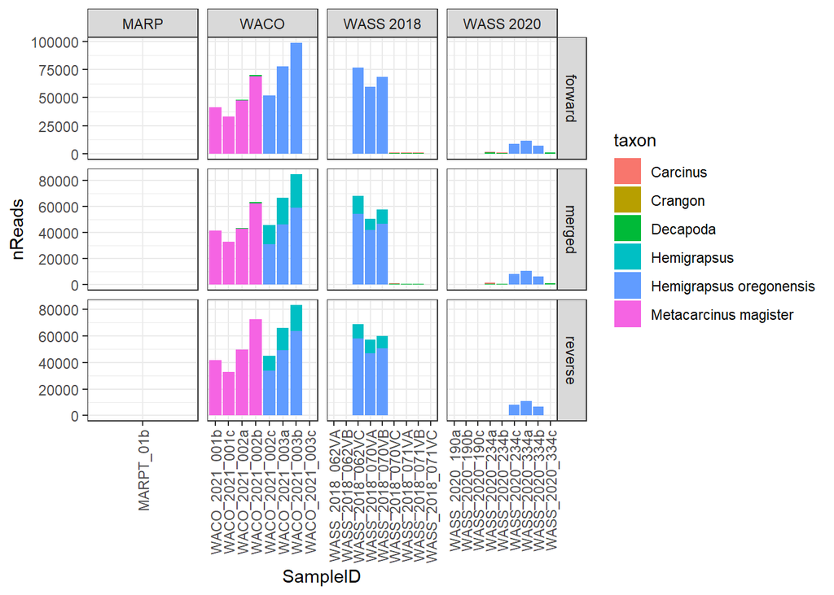

```r
ggplot(data=filter(dat_filter, order=="Decapoda"), aes(x=SampleID, y=nReads, fill=taxon)) +
  geom_col() +
  facet_grid(rows=vars(dataset), cols=vars(Group), scales="free") +
  theme_bw() + theme(axis.text.x=element_text(angle=90,hjust=1,vjust=0.5))
```

I’m going to remove *Carcinus* hashes, as well as the non-specific *Decapoda*.

```r
dat_filter %<>% filter(!(taxon %in% c("Decapoda","Carcinus")))
```

**BACTERIA** check to see if there are any other bacterial taxa.

```r
dat_filter %>% pull(phylum) %>% unique()
```

```
##  [1] "Arthropoda"      "Bacteroidetes"   "Cnidaria"        "Bacillariophyta"
##  [5] "Rhodophyta"      "Oomycota"        "Annelida"        "Rotifera"
##  [9] "Ascomycota"      "Proteobacteria"  "Discosea"
```

Take out everything in *Bacteroidetes*, *Discosea* (amoebas),*Proteobacteria*. I’m not sure what to do about the fungi…

```r
dat_filter %<>% filter(!(phylum %in% c("Bacteroidetes","Discosea","Proteobacteria")))
```

I think I’ll remove the fungi too, for now.

```r
dat_filter %<>% filter(!(phylum %in% c("Oomycota","Ascomycota")))
```

```r
dat_filter %>% pull(phylum) %>% unique()
```

```
## [1] "Arthropoda"      "Cnidaria"        "Bacillariophyta" "Rhodophyta"
## [5] "Annelida"        "Rotifera"
```

So we’re left with arthropods, cnidarians, rotifers, worms, and algae.

**HIGHER TAXONOMIC RANK**

It isn’t super helpful to have anything above genus, but I’ll keep in families too.

```r
dat_filter %<>% filter(rank %in% c("family","genus","species"))
```

## Select Taxa

### Green Crab

```r
egc_mock <- c()
```

```r
egc_dat <- dat_filter %>% filter(Group %in% c("WACO","WASS 2018","WASS 2020"))
```

What is the full list of taxa present?

```r
unique(egc_dat$taxon)
```

```
##  [1] "Metacarcinus magister"          "Ampithoe lacertosa"
##  [3] "Monocorophium acherusicum"      "Metrocoris sp. Kotumsar"
##  [5] "Navicula ramosissima"           "uncultured Bangiophyceae"
##  [7] "Leptacis"                       "Platynereis sp. CMC02"
##  [9] "Hemigrapsus oregonensis"        "Hemigrapsus"
## [11] "Amblychia subrubida"            "Euchlanis dilatata"
## [13] "Melosira nummuloides"           "Praya dubia"
## [15] "Pemphredon"                     "Aglaophenia tubulifera"
## [17] "Hydraena lapidicola"            "Chorsia sp. BOLD:AAL7037"
## [19] "Balanus"                        "Euglossa igniventris"
## [21] "Stylaster venustus"             "Cryptophagidae"
## [23] "Nitzschia sp. NIES-3581"        "Cyclotella sp. MBTD-CMFRI-S080"
## [25] "Stegodyphus lineatus"           "Pyrisitia nise"
## [27] "Crangon"                        "Eumida"
## [29] "Pleurosigma"                    "Nitzschia cf. promare"
## [31] "Chaetoceros socialis"           "Nitzschia"
## [33] "Pseudo-nitzschia"               "Amphiascopsis cinctus"
## [35] "Skeletonema"                    "Paracorophium excavatum"
## [37] "Bacillariaceae"                 "Chironomidae"
## [39] "Gomphonema clevei"              "Guinardia delicatula"
## [41] "Naviculaceae"                   "Balanus crenatus"
## [43] "Balanus glandula"
```

Calculate read proportions

```r
reads_per_sample <- egc_dat %>%
  group_by(Group, Sample_name, SampleID, dataset) %>%
  summarise(sumReads=sum(nReads))
egc_pdat <- egc_dat %>%
  left_join(reads_per_sample, by=c("Group","Sample_name","SampleID","dataset")) %>%
  group_by(Group, Sample_name, SampleID, dataset, sumReads, rank, taxon) %>%
  summarise(tReads=sum(nReads)) %>%
  mutate(pReads=tReads/sumReads)
```

Rejoin full taxonomic information to the taxon.

```r
tax_simple <- dat_filter %>%
  dplyr::select(rank,taxon,kingdom,phylum,class,order,family,genus,species) %>%
  distinct()

egc_pdat %<>% left_join(tax_simple,by=c("rank","taxon"))

unique(egc_pdat$phylum)
```

```
## [1] "Arthropoda"      "Bacillariophyta" "Annelida"        "Rhodophyta"
## [5] "Cnidaria"        "Rotifera"
```

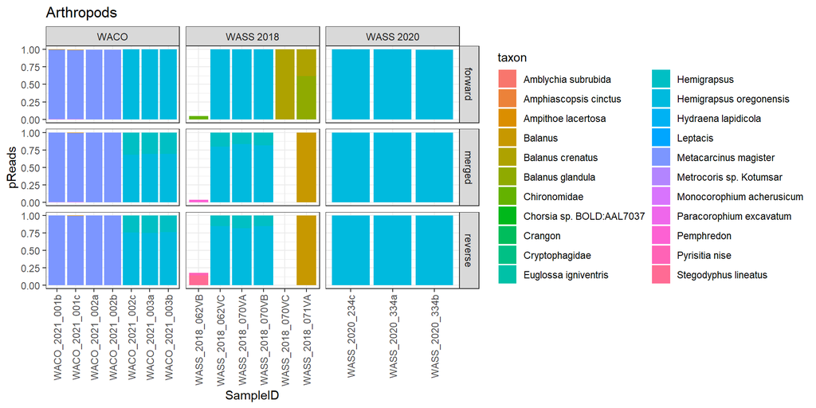

```r
egc_mock <- c("Metacarcinus magister","Hemigrapsus oregonensis")
```

Without the crab species?

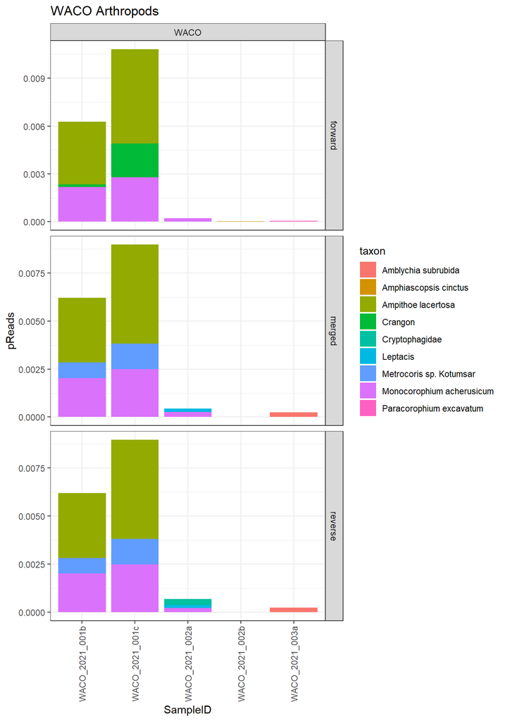

```r
plotdat <- egc_pdat %>%
  filter(phylum %in% c("Arthropoda") & !(family %in% c("Cancridae","Varunidae"))) %>%
  filter(Group=="WACO")
ggplot(data=plotdat, aes(x=SampleID, y=pReads, fill=taxon)) +
  geom_col() + facet_grid(col=vars(Group), rows=vars(dataset), scales="free") +
  ggtitle("WACO Arthropods") +
  theme_bw() + theme(axis.text.x=element_text(angle=90,hjust=1,vjust=0.5))
```

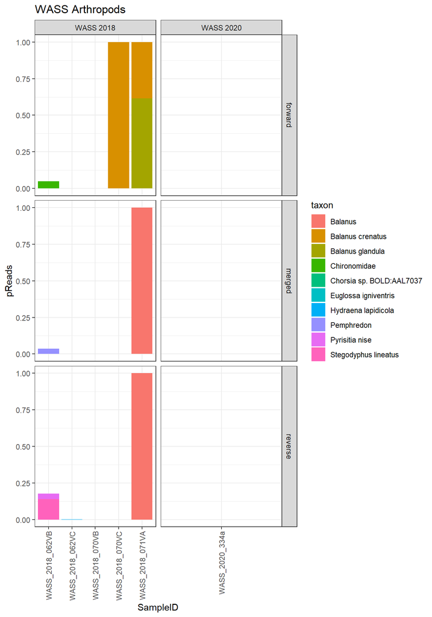

```r
plotdat <- egc_pdat %>%
  filter(phylum %in% c("Arthropoda") & !(family %in% c("Cancridae","Varunidae"))) %>%
  filter(Group %in% c("WASS 2018","WASS 2020"))
ggplot(data=plotdat, aes(x=SampleID, y=pReads, fill=taxon)) +
  geom_col() + facet_grid(col=vars(Group), rows=vars(dataset), scales="free") +
  ggtitle("WASS Arthropods") +
  theme_bw() + theme(axis.text.x=element_text(angle=90,hjust=1,vjust=0.5))
```

*amblychia* are moths, *metrocoris* is some kind of insect, *leptacis* are parasitoid wasps, *pemphredon* are digger wasps, and *Euglossia* is a bee species…

```r
egc_mock <- c(egc_mock, "Ampithoe lacertosa","Monocorophium acherusicum","Balanus crenatus","Balanus glandula")
```

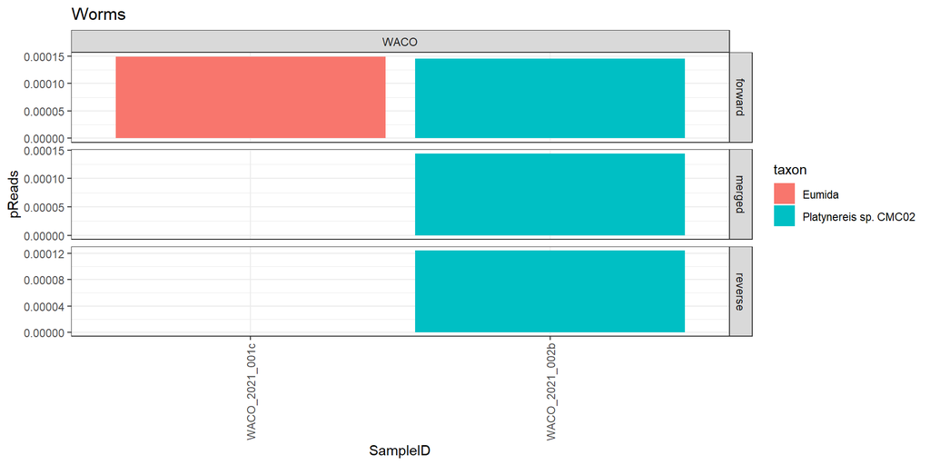

*Platynereis* is a genus of marine annelid worms.

```r
egc_mock <- c(egc_mock,"Platynereis sp.")
```

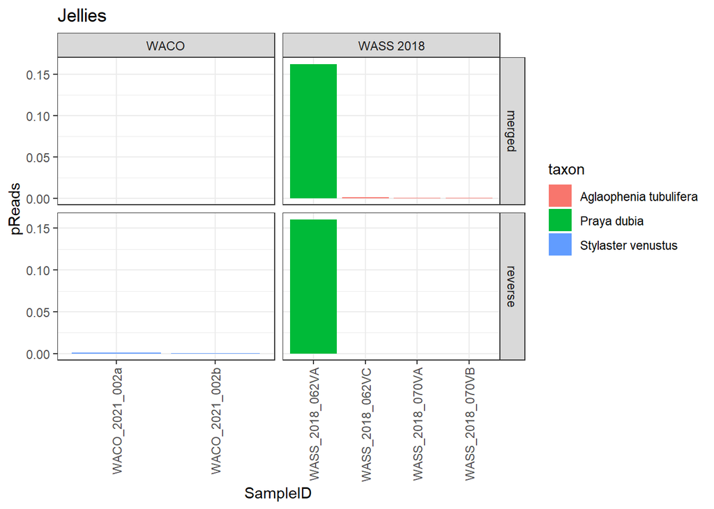

well, *praya dubia* is a giant siphonophore that lives in the deep sea, so…

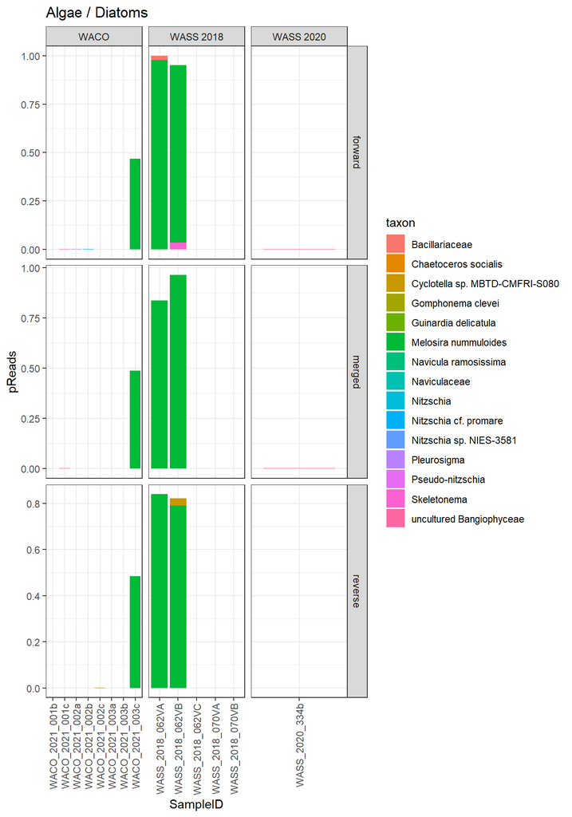

```r
egc_mock <- c(egc_mock, "Melosira nummuloides", "Bangiophyseae sp.","Bacillariaceae")
```

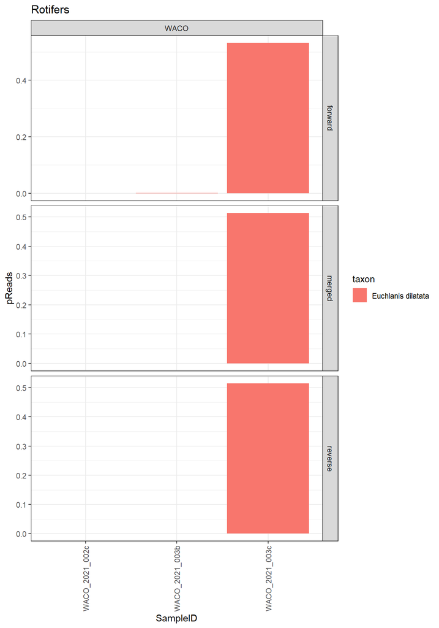

```r
egc_mock <- c(egc_mock, "Euchlanis dilatata")
```

```r
ggplot(data=filter(egc_pdat, is.na(phylum)), aes(x=SampleID, y=pReads, fill=taxon)) +
  geom_col() + facet_grid(col=vars(Group), rows=vars(dataset), scales="free") +
  ggtitle("Missing Phylum") +
  theme_bw() + theme(axis.text.x=element_text(angle=90,hjust=1,vjust=0.5))
```

[output not shown]

```r
egc_mock <- c(egc_mock, "Coscinodiscophyceae","Mediophyceae")
```

## Missing taxa

```r
egc_mock <- c(egc_mock,"Mya arenaria","Ruditapes philippinarum","Aglaophenia tubulifera")
```

#### save list of species

```r
write.csv(egc_mock, here(outdir,"LerayXT_draft_mock_community_EGC.csv"), row.names=FALSE)
```

#### save proportional prey data set

Save the proportions of reads per taxon, per Group (across samples) – by dataset

```r
reads_per_group <- egc_dat %>%
  group_by(Group, dataset) %>%
  summarise(sumReads=sum(nReads))

egc_summary_pdat <- egc_dat %>%
  group_by(Group, dataset, rank, taxon) %>%
  summarise(taxonReads=sum(nReads)) %>%
  left_join(reads_per_group, by=c("Group","dataset")) %>%
  mutate(pReads=taxonReads/sumReads)

write.csv(egc_summary_pdat, here(outdir,"LerayXT_mock_community_taxa_EGC.csv"), row.names=FALSE)
```

## Dungeness Crab

```r
dungy_dat <- dat_filter %>% filter(Group %in% c("MARP"))
```

What is the full list of taxa present?

```r
unique(dungy_dat$taxon)
```

```
## [1] "Euchlanis dilatata"       "uncultured Bangiophyceae"
## [3] "Naididae"                 "Stegodyphus lineatus"
## [5] "Limnodrilus hoffmeisteri"
```

Calculate read proportions

```r
dungy_reads_per_sample <- dungy_dat %>%
  group_by(Group, Sample_name, SampleID, dataset) %>%
  summarise(sumReads=sum(nReads))
dungy_pdat <- dungy_dat %>%
  left_join(dungy_reads_per_sample, by=c("Group","Sample_name","SampleID","dataset")) %>%
  group_by(Group, Sample_name, SampleID, dataset, sumReads, rank, taxon) %>%
  summarise(tReads=sum(nReads)) %>%
  mutate(pReads=tReads/sumReads)
```

Rejoin full taxonomic information to the taxon.

```r
tax_simple <- dat_filter %>%
  dplyr::select(rank,taxon,kingdom,phylum,class,order,family,genus,species) %>%
  distinct()

dungy_pdat %<>% left_join(tax_simple,by=c("rank","taxon"))

unique(dungy_pdat$phylum)
```

```
## [1] "Rotifera"   "Rhodophyta" "Annelida"   "Arthropoda"
```

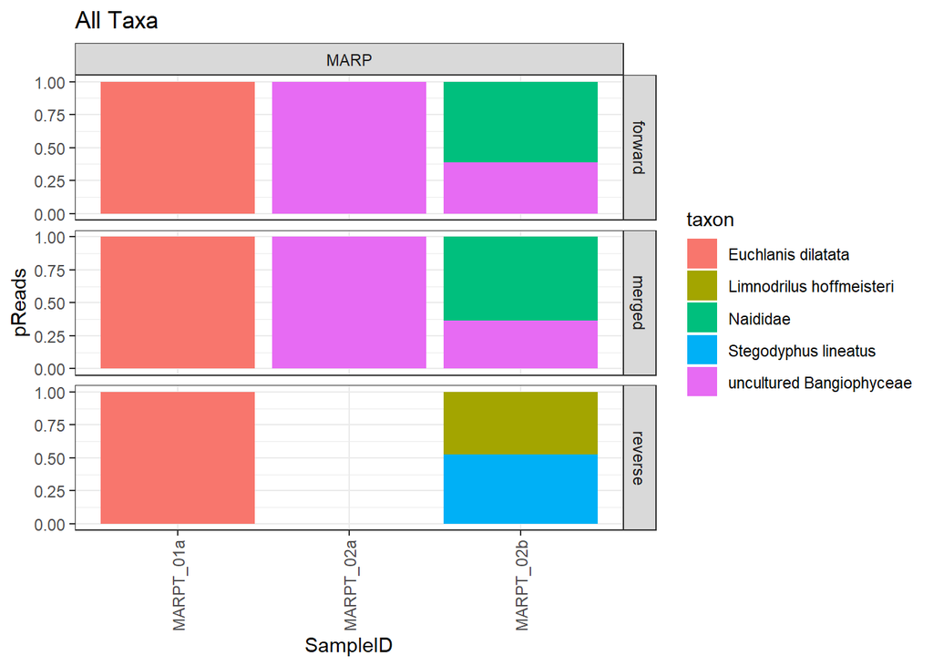

```r
dungy_mock <- c("uncultured Bangiophyceae","Naididae","Euchlanis dilatata")
```

#### save list of species

```r
write.csv(dungy_mock, here(outdir,"LerayXT_draft_mock_community_Dungies.csv"), row.names=FALSE)
```

#### save proportional prey data set

Save the proportions of reads per taxon, per Group (across samples) – by dataset

```r
dungy_reads_per_group <- dungy_dat %>%
  group_by(Group, dataset) %>%
  summarise(sumReads=sum(nReads))

dungy_summary_pdat <- dungy_dat %>%
  group_by(Group, dataset, rank, taxon) %>%
  summarise(taxonReads=sum(nReads)) %>%
  left_join(dungy_reads_per_group, by=c("Group","dataset")) %>%
  mutate(pReads=taxonReads/sumReads)

write.csv(egc_summary_pdat, here(outdir,"LerayXT_mock_community_taxa_Dungies.csv"), row.names=FALSE)
```